# Class 9

Unsupervised learning mini-project

Yi Fu

4/30/2019

First, let’s check if “factoextra” and “rgl” package are installed. And then, load the packages.

```r
library("factoextra")
library("rgl")
knitr::knit_hooks$set(webgl = hook_webgl)
```

## Preparing the data for Human Breast Cancer Cells

The **WisconsinCancer.csv** containts values describing characteristics of the cell nuclei present in digitized images of a fine needle aspiration (FNA) of a breast mass. There are 569 samples. Among these, there are 212 malignant samples and 357 benign samples.

```r
df = read.csv("data/WisconsinCancer.csv")
data = as.matrix(df[,3:32])
rownames(data) = df$id
diagnosis = as.numeric(df$diagnosis=="M")
```

**It is important to check if the data need to be scaled before performing PCA.**

The following suggests that the data should be scaled.

```r
as.vector(round(apply(data,2,mean)))
```

```
##  [1]  14  19  92 655   0   0   0   0   0   0   0   1   3  40   0   0   0
## [18]   0   0   0  16  26 107 881   0   0   0   0   0   0
```

```r
as.vector(round(apply(data,2,sd)))
```

```
##  [1]   4   4  24 352   0   0   0   0   0   0   0   1   2  45   0   0   0
## [18]   0   0   0   5   6  34 569   0   0   0   0   0   0
```

So, let’s scale the data

```r
data.scaled = scale(data)
```

## Performing PCA

Let’s use the *prcomp()* function.

```r
pca = prcomp(data.scaled)
summary(pca)
```

```
## Importance of components:
##                           PC1    PC2     PC3     PC4     PC5     PC6
## Standard deviation     3.6444 2.3857 1.67867 1.40735 1.28403 1.09880
## Proportion of Variance 0.4427 0.1897 0.09393 0.06602 0.05496 0.04025
## Cumulative Proportion  0.4427 0.6324 0.72636 0.79239 0.84734 0.88759
##                            PC7     PC8    PC9    PC10   PC11    PC12
## Standard deviation     0.82172 0.69037 0.6457 0.59219 0.5421 0.51104
## Proportion of Variance 0.02251 0.01589 0.0139 0.01169 0.0098 0.00871
## Cumulative Proportion  0.91010 0.92598 0.9399 0.95157 0.9614 0.97007
##                           PC13    PC14    PC15    PC16    PC17    PC18
## Standard deviation     0.49128 0.39624 0.30681 0.28260 0.24372 0.22939
## Proportion of Variance 0.00805 0.00523 0.00314 0.00266 0.00198 0.00175
## Cumulative Proportion  0.97812 0.98335 0.98649 0.98915 0.99113 0.99288
##                           PC19    PC20   PC21    PC22    PC23   PC24
## Standard deviation     0.22244 0.17652 0.1731 0.16565 0.15602 0.1344
## Proportion of Variance 0.00165 0.00104 0.0010 0.00091 0.00081 0.0006
## Cumulative Proportion  0.99453 0.99557 0.9966 0.99749 0.99830 0.9989
##                           PC25    PC26    PC27    PC28    PC29    PC30
## Standard deviation     0.12442 0.09043 0.08307 0.03987 0.02736 0.01153
## Proportion of Variance 0.00052 0.00027 0.00023 0.00005 0.00002 0.00000
## Cumulative Proportion  0.99942 0.99969 0.99992 0.99997 1.00000 1.00000
```

> From your results, 44.27% of the original variance is captured by the first principal components.

> 7 principal components are required to describe at least 90% of the original variance in the data.

Here is the plot for the percentage of variance captured by each PC:

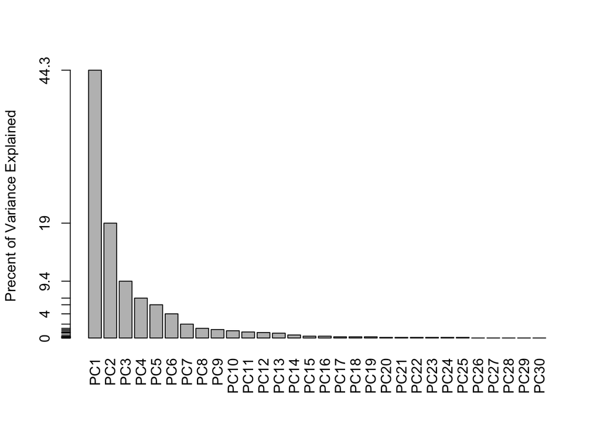

```r
pca.var = pca$sdev^2
pca.var.per = round(pca.var/sum(pca.var)*100, 1)
barplot(pca.var.per,
        ylab="Precent of Variance Explained", names.arg=paste0("PC",1:length(pca.var.per)),
        las=2, axes = FALSE)
axis(2, at=pca.var.per, labels=round(pca.var.per,2))
```

Here is the side-by-side plot for the percentage and cumulative percentage of variance captured by each PC:

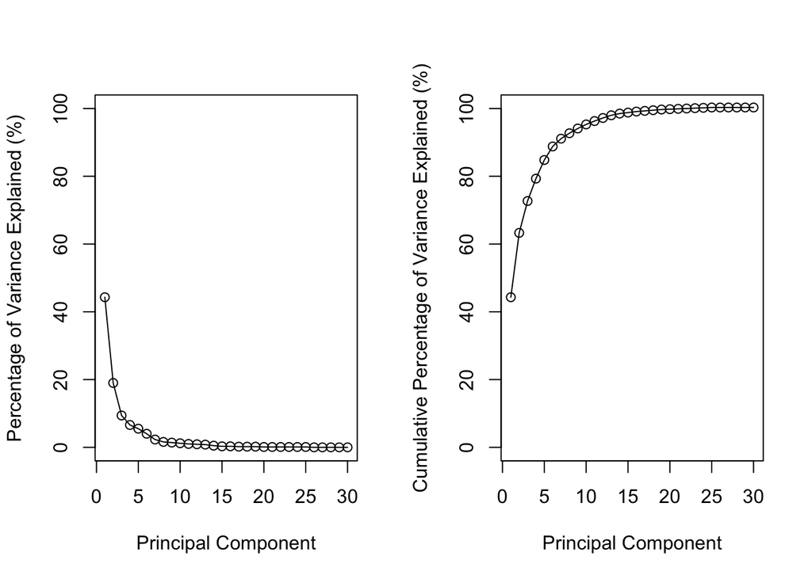

```r
par(mfcol=c(1,2))
plot(pca.var.per,
     xlab="Principal Component", ylab="Percentage of Variance Explained (%)", ylim=c(0, 100),
     type="o")
plot(cumsum(pca.var.per),
     xlab="Principal Component", ylab="Cumulative Percentage of Variance Explained (%)", ylim=c(0, 100),
     type="o")
```

Here is the plot generated by “factoextra” package:

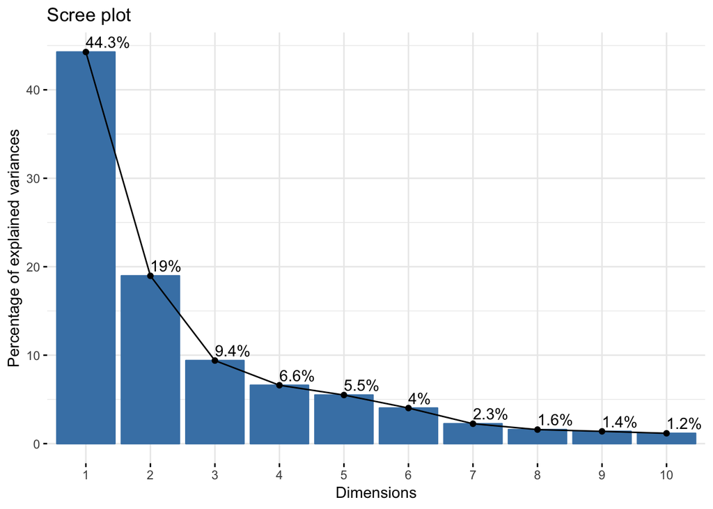

```r
fviz_eig(pca, addlabels = TRUE)
```

Here is the biplot:

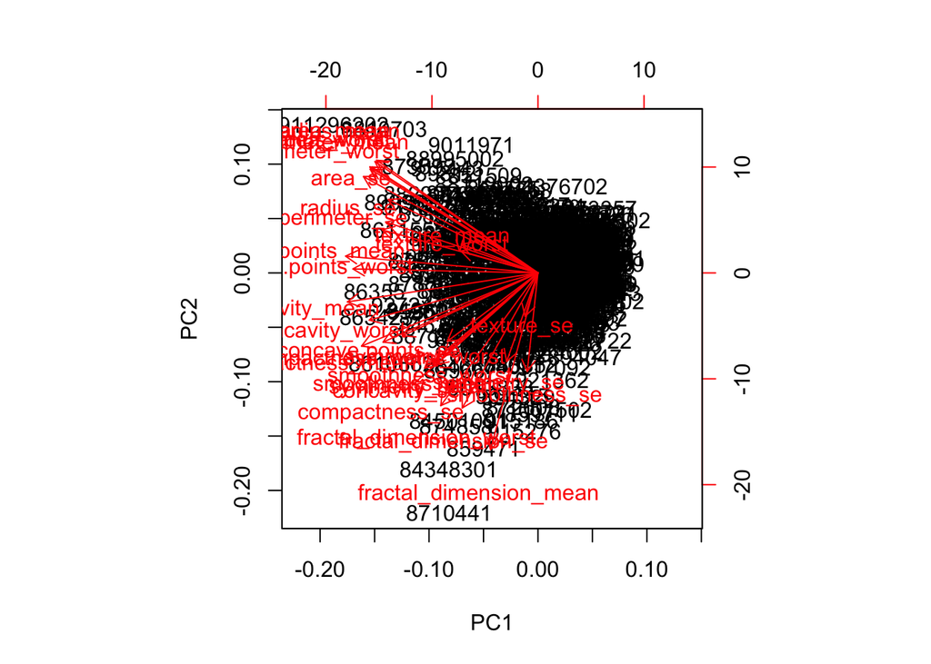

```r
biplot (pca)
```

Here is the plot:

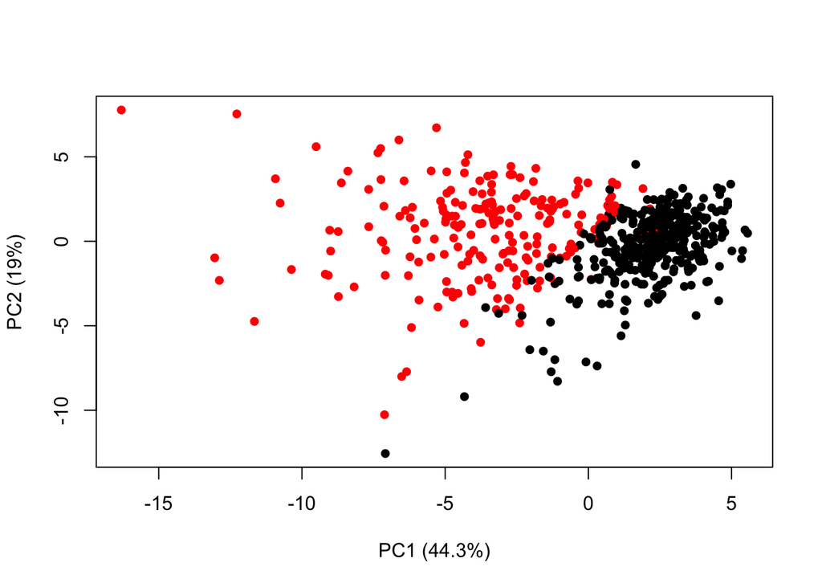

```r
plot (pca$x[,1], pca$x[,2],
      xlab=paste0("PC1 (", pca.var.per[1], "%)"), ylab=paste0("PC2 (", pca.var.per[2], "%)"),
      col=diagnosis + 1, pch=16)
```

Here is the plot (PC1 vs PC3):

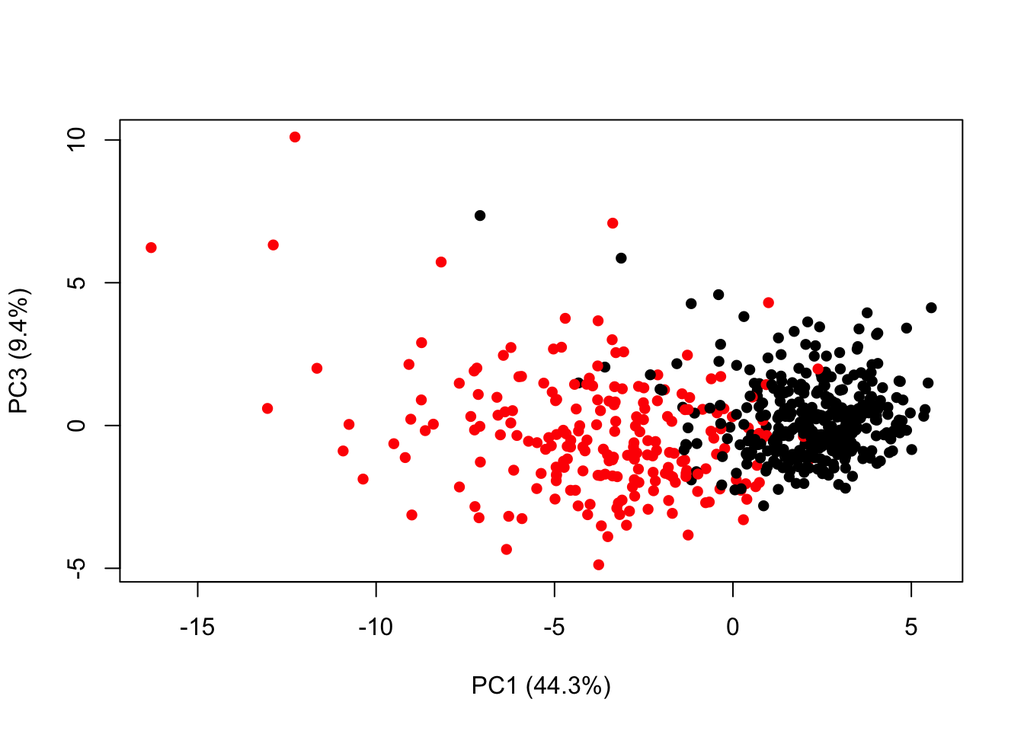

```r
plot (pca$x[,1], pca$x[,3],
      xlab=paste0("PC1 (", pca.var.per[1], "%)"), ylab=paste0("PC3 (", pca.var.per[3], "%)"),
      col=diagnosis + 1, pch=16)
```

Here is the 3D plot (PC1 vs PC2 vs PC3):

```r
plot3d(pca$x[,1], pca$x[,2], pca$x[,3],
       xlab=paste0("PC1 (", pca.var.per[1], "%)"), ylab=paste0("PC2 (", pca.var.per[2], "%)"),
       zlab=paste0("PC3 (", pca.var.per[3], "%)"),
       col=diagnosis + 1, cex=1.5, size=1, type="s")

# this is needed to generate the plot in regular .r file.
#rglwidget(width = 400, height = 400)
```

[interactive chart not shown]

## Performing Hierarchical Clustering

We need a distance matrix not the raw data as input.

```r
dist = dist(data.scaled)
```

Let’s use the *hclust()* function.

```r
hc = hclust(dist, method="complete")
```

Here is the plot:

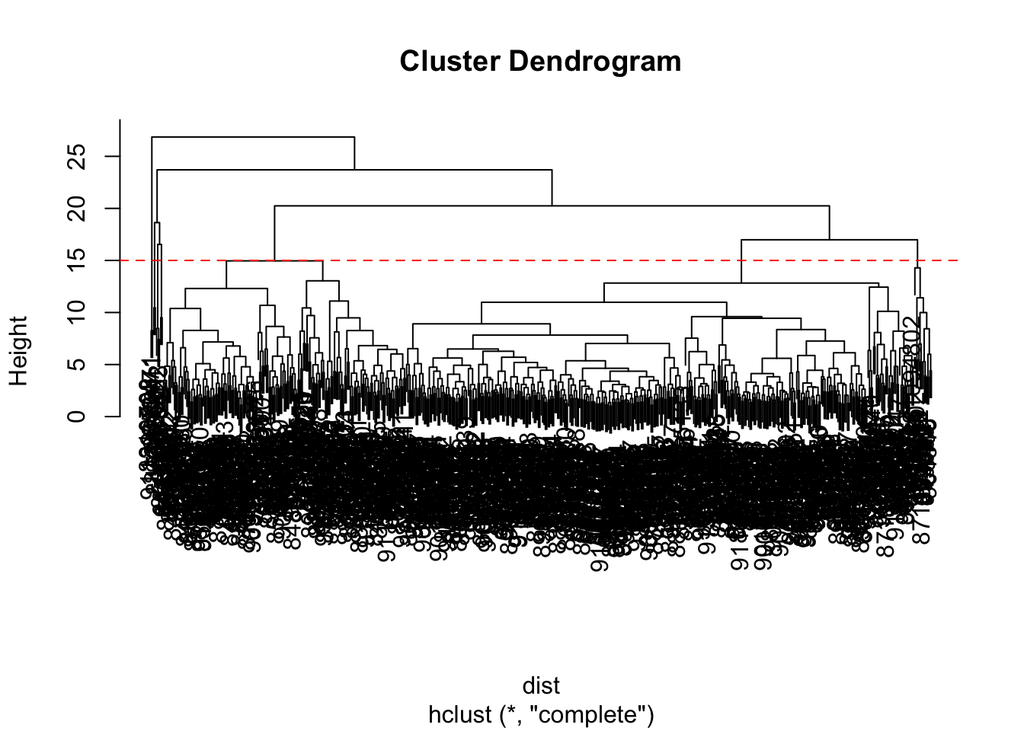

```r
plot(hc)
abline(h=15, col="red", lty=2)
```

Let’s compare the known clusters with hierarchically generated clusters. The following is the best cluster vs diagnoses match with by cutting into a different number of clusters between 2 and 10:

```r
gp5 = cutree(hc, 5)
table(gp5, diagnosis)
```

```
##    diagnosis
## gp5   0   1
##   1  12 165
##   2   0   5
##   3 343  40
##   4   2   0
##   5   0   2
```

## Performing K-mean Clustering

Let’s use the *kmeans()* function.

```r
two_means = kmeans(data.scaled, centers=2, nstart=20)
```

Let’s compare the known clusters with 2-mean clusters.

```r
table(two_means$cluster, diagnosis)
```

```
##    diagnosis
##       0   1
##   1 343  37
##   2  14 175
```

Let’s compare hierarchically generated clusters with 2-mean clusters.

```r
gp2 = cutree(hc, 2)
table(gp2, two_means$cluster)
```

```
##
## gp2   1   2
##   1 380 187
##   2   0   2
```

```r
gp4 = cutree(hc, 4)
table(gp4, two_means$cluster)
```

```
##
## gp4   1   2
##   1  17 160
##   2   0   7
##   3 363  20
##   4   0   2
```

## Combining PCA and Hierarchical Clustering

Using the minimum number of principal components required to describe at least 90% of the variability in the data, create a hierarchical clustering model with the linkage method=“ward.D2”. We use Ward’s criterion here because it is based on multidimensional variance like principal components analysis. Assign the results to hc.ward.

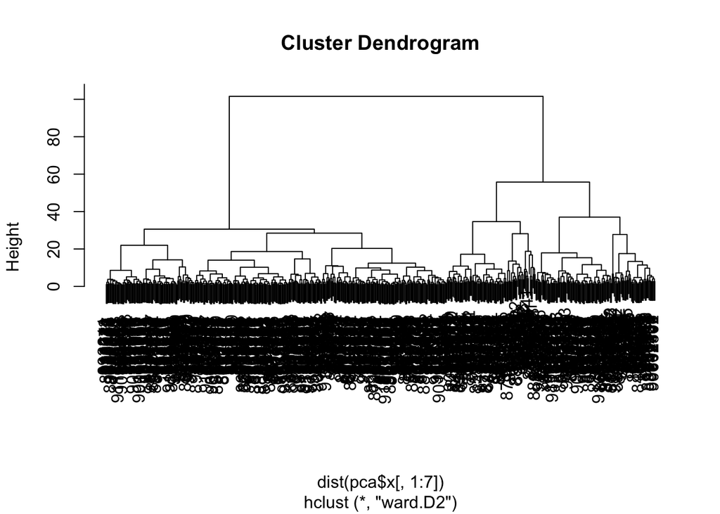

```r
hc.ward = hclust(dist(pca$x[,1:7]), method="ward.D2")
plot(hc.ward)
```

Let’s compare the known clusters with hierarchically generated clusters (ward.D2).

```r
gp2.ward = cutree(hc.ward, k=2)
table(gp2.ward, diagnosis)
```

```
##         diagnosis
## gp2.ward   0   1
##        1  28 188
##        2 329  24
```

Let’s compare hierarchically generated clusters (ward.D2) with PCA.

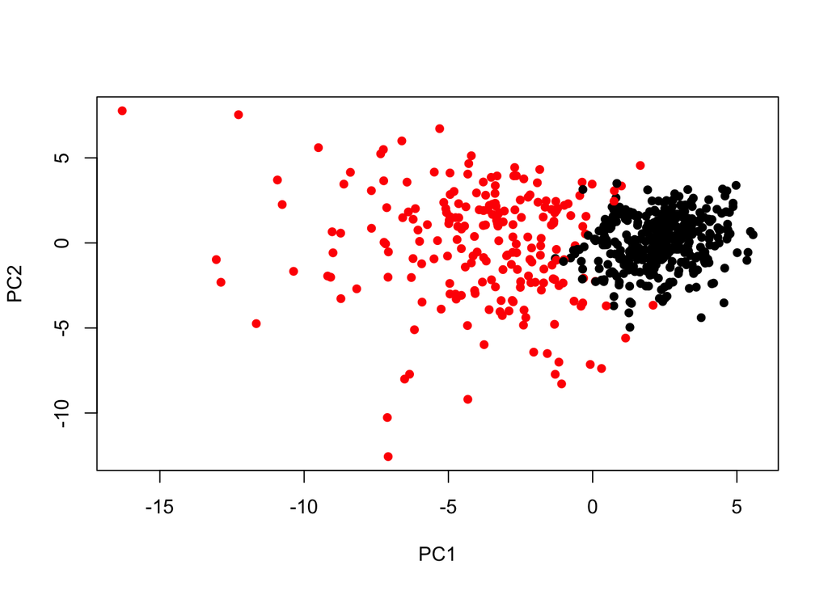

```r
plot(pca$x[,1:2], col = -gp2.ward + 3, pch=16)
```

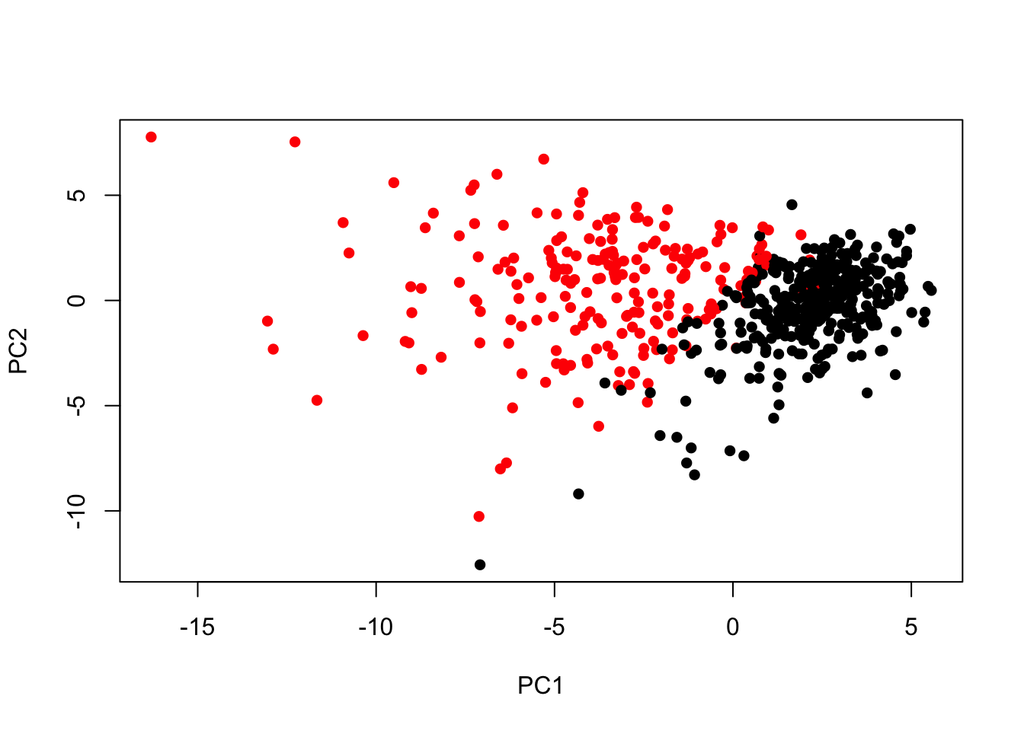

```r
plot(pca$x[,1:2], col = diagnosis + 1, pch=16)
```